# Exploration of California’s Contributions to 2016 Presidential Campaigns by Alf

# Multivariate Analysis

#### Talk about some of the relationships you observed in this part of the investigation. Were there features that strengthened each other in terms of looking at your feature(s) of interest?

I really would like to have gathered more information about demographics, not only gender or income groups. I may have already stretched my inferences a bit by trying to see a connection between zip codes and total campaign contributions. I might still find a connection by mapping more data points.

I tried to compare income levels against total contribution amounts by regions. I specifically zoomed into the San Francisco Bay Area since this is considered to be one of the most diverse populous regions in the nation and the world.

#### Were there any interesting or surprising interactions between features?

The dataset so far shows a very strong support for the Democratic candidates in California. Both Democrat Clinton and Sanders are still in the race (as of March 15 2016). The top Republican fundraisers have dropped out of the presidential race. But Trump, the clear Republican frontrunner, does not seem to have a campaign in California.

# Final Plots and Summary

### Which party has received the most funds?

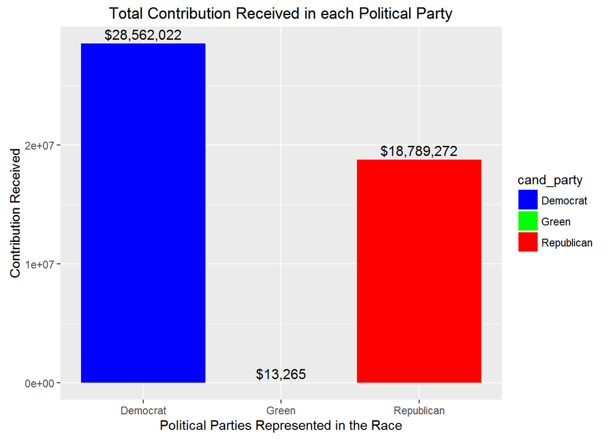

### Description One

This plot illustrates that the Democratic party is outraising the Republican party. If money was the only factor in winning, a Democrat will take California in the general Presidential Election. But with the current news in the primary elections, Trump is gaining a lot of support with very little fundraising. See plot below.

### Who has the most funds within his or her respective party?

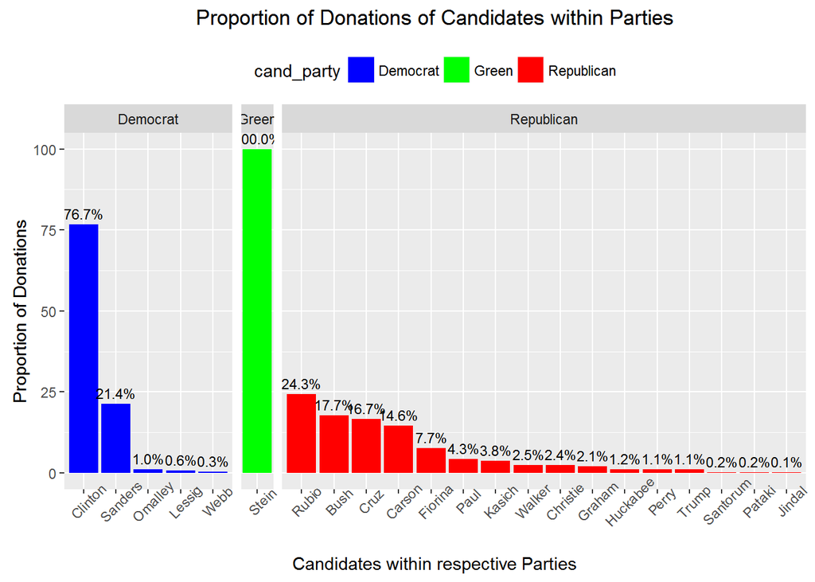

### Description Two

In one plot, this image illustrates bizarre 2016 presidential race. On the Democratic side, the histogram matches the current trend. The top 2 fundraisers are still in the race with Clinton as the popular and delegate frontrunner. The other 3 Democratic candidates have suspended campaigns with poor showing in the primaries, which matched their poor total donation received in California.

On the Republican side, the plot shows the reverse of a trend. The clear Republican frontrunner, Trump, has raised very little funds compared to his top competitors, Rubio, Bush, Cruz and Carson. The top republican fundraiser, Rubio, has dropped out of the race. Cruz still remains in the race. Kasich, who has won a few delegates, is hanging in there (as of March 16 2016). He needs to do a better job with raising funds to demonstrate his viability as the Republican presidential nominee.

### Where’s the money?

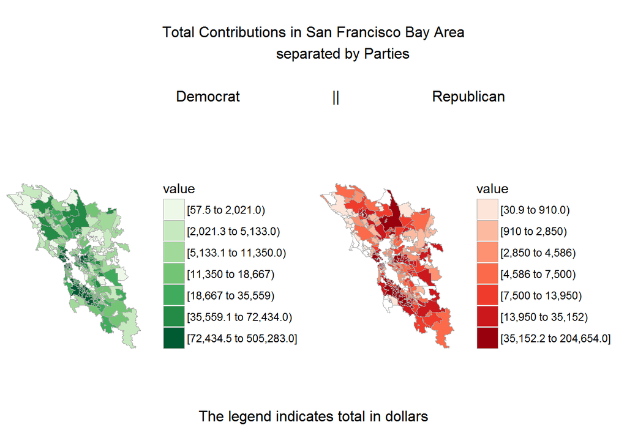

### Description Three

This last plot is a map of the San Francisco Bay Area which includes the following counties: Alameda, Contra Costa, Marin, Napa, San Francisco, San Mateo, Santa Clara, Solano, and Sonoma. Alameda county comprises the cities of Alameda, Albany, Berkeley, Dublin, Emeryville, Fremont, Hayward, Livermore, Newark, Oakland, Piedmont, Pleasanton, San Leandro, Union City – cities across the East of the San Francisco Bay. The county is considered to be the most diverse in the nation. Alameda county and the other counties surrounding the San Francisco Bay is the one of the most populous regions in the nation. See: http://www.theatlantic.com/national/archive/2014/04/mapping-racial-diversity-by-county/361388/

I arranged two maps of the Bay Area side-by-side to show the difference in total contribution amounts between Democrats and Republicans. Here’s the total for each party in the counties surrounding the San Francisco Bay Area.

**Democrats**

```
## [1] "$12,376,673"
```

**Republicans**

```
## [1] "$4,377,246"
```

Overall, the Democrats raised very well throughout the Bay Area. However, what stands out especially is that in the southern part of the Bay Area south of San Jose along 101 in Santa Clara county, the Republicans outraised the Democrats.

# Reflection

## Struggles

This project is perhaps the most time-consuming of all the Udacity projects I have ever done – **spending nearly 120 hours**. R is very powerful and robust. But with power comes chaos. The lectures need updating. It is bad enough that R is confusing lexically and syntactically. The lectures use packages, libraries, and functions that do not match the lecture notes.

I also struggled with the lectures because I had very little idea of what facebook is. I initially thought it was a dating site. So I did problem sets 1 through 3 assuming that facebook was a dating site, and hence had very little understanding what the plots meant. It was not until lecture 4 when I posted a question regarding sentiment analysis of the NFL that I had a better idea of what facebook is. I also asked a few friends to show me how they use facebook. This actually made me appreciate the facebook dataset a little bit more.

I could not do lecture 6 because the hands of the lecturer gave me motion sickness. In fact, all the lectures from Project 0 to Project 4 had a lot of hand gestures especially when they zoom in on the screen. It was hard to concentrate because I felt dizzy many times. But I believe that the hands of all the lecturers in all the lectures for Project 4 are the most distracting and motion-sickness inducing so far. I am hoping that Projects 5, 6 and 7 will be different.

Another problem I had is the resources that R and R-studio require. I had to use a Windows, Linux, and a Mac to work on this project. Moreover, R did not behave in Windows in the same manner as in Linux. This was quite frustrating. We should have been warned.

Although R is great in terms of producing quick beautiful plots, the path to get to it is rather torturous and tortuous. There was not much guidance from Udacity coaches as there are no live webcasts. Moreover, coaches were not even available for appointments. I am assuming that since I live in Hawaii that there are no time slots available for my time zone.

The forums were not much help since it is rather disorganized. I am glad that the initial plots are “stream-of-consciousness analysis and exploration of the data” as Project Details suggested. This allowed me to experiment a lot. Because of this experimentation, I learned a lot about the R program.

## Few Successes and Some Ideas

The data I chose was from fec.gov to explore financial contributions to the 2016 presidential campaigns. This was particularly interesting since this presidential election is the most bizarre in recent memory.

The California dataset has more than 180,000 observations, originally with 18 variables. I downloaded the dataset on February 26, 2016. The last filing was the last monthly report at the end of January 2016.

California is the most populous state in United States of America (USA). It also happens to be the most diverse in general as a state. But I discovered while doing this project that California has enclaves of demographics. So perhaps it is a microcosm of the nation since USA has enclaves of demographics also. I thought that, by examining the financial data of California, I would get a better idea of what will happen during the rest of primary season.

As soon as I examined the data, I noticed immediately that the Democrats outraised the Republicans. There was definitely more activity in Sanders’ and Clinton’s campaign. It would have been interesting to see the demographics of all the campaigns. The only demographics I had was gender which was obtained probabilistically using first names from an R package. But I think its results were indicative of the gender makeup of the contributors. This may have been confirmed by the higher proportion of females who contributed to Hillary Clinton’s campaign. Carly Fiorina did not provide any evidence since she raised very little funds from anyone.

There were some “unknown” gender that I marked “unknown” if the *gender* package could not determine the gender of the contributor. I am assuming that the first names were foreign sounding that it was not predicted from SSA method (social security?). These contributors with *unknown* gender primarily donated to Sanders and Clinton. This might intimate some ethnic demographics perhaps?

The other demographics I was interested in was ethnic demographics. There were no packages to determine the ethnicity of contributors. The other dataset I used was the dataset from census.gov. I obtained the income data to find out if there is an association between income bracket and total contribution. The attempt was there. I am not sure I succeeded. There are also ethnic demographics data available in *chorolethr* and *choroplethrZip* packages. Examining that data might give some light on how a region might vote. I would compare that data with the FEC dataset and see if there are any correspondences between contribution counts/amount and the demographics of counties.

I thought I needed to look at Southern California which I heard was relatively more Republican than Democrat compared to Northern California. Of course, I checked the county results in wikipedia both 2008 and 2012 elections: https://en.wikipedia.org/wiki/United_States_presidential_election_in_California,_2012. Analysing the data as Northern vs Southern California is not that simplistic. From the Wikipedia articles, it looks like it depends by county.

Nevertheless, looking at the proportion of the contributors’ cities, among the top 20 donor cities are cities in Southern California, like Beverly Hills, Newport Beach, Pasadena, and San Diego which proportionally gave more to Republicans; while cities in Northern California, like San Francisco, Oakland, and Berkeley, proportionally gave more to Democrats.

In the San Francisco Bay Area, the donors in total gave nearly 44% of the total contribution in California; while the Republican donors in San Francisco Bay Area only raised 23% of their total in California. This is quite telling.

All the trends I discovered from this dataset may correspond to the outcome of the California primaries on June 7 2016. If the primaries are run by counties, it would be interesting to examine the counties more closely to see if there is a correspondence between contribution counts/amounts and primary results. I explored the data in the San Francisco Bay Area counties. Let’s wait and see if the financial support will match voter support in the primaries. Trump with very little fundraising activity in California is the clear frontrunner in the Republican side. How far can he go in California without financial contributions? And can the Green Party ever win? The Green Party raised less than .03% of the combined total of contributions. Perhaps the Green Party staff members want to finish this presidential campaign with very little carbon footprints. Inactivity will guarantee that.

# Resources

- Udacity’s course Data Analysis with R
- http://www.statmethods.net/
- http://vita.had.co.nz/papers/tidy-data.pdf
- http://flowingdata.com/2007/12/11/netflix-prize-dataset-visualization/
- https://www.facebook.com/notes/facebook-data-science/coordinated-migration/10151930946453859
- http://blog.revolutionanalytics.com/2013/08/foodborne-chicago.html
- https://cran.r-project.org/web/packages/textcat/textcat.pdf
- http://lightonphiri.org/blog/ggplot2-multiple-plots-in-one-graph-using-gridextra
- http://docs.ggplot2.org/current/scale_continuous.html
- http://docs.ggplot2.org/
- https://en.wikipedia.org/wiki/Linear_regression#Assumptions
- https://en.wikipedia.org/wiki/Normal_distribution
- http://flowingdata.com/2008/02/15/how-to-read-and-use-a-box-and-whisker-plot/
- https://s3.amazonaws.com/udacity-hosted-downloads/ud651/DataWranglingWithR.pdf
- http://docs.ggplot2.org/current/coord_trans.html
- http://hci.stanford.edu/publications/2013/invisibleaudience/invisibleaudience.pdf
- http://www.r-bloggers.com/hadley-wickham-presents-dplyr-at-user-2014/
- http://www.r-bloggers.com/r-function-of-the-day-cut-2/
- https://www.facebook.com/notes/facebook-data-science/the-emotional-highs-and-lows-of-the-nfl-season/10152033221418859
- http://www.r-statistics.com/2013/05/log-transformations-for-skewed-and-wide-distributions-from-practical-data-science-with-r/
- http://www.r-bloggers.com/running-totals-in-r/
- https://cran.r-project.org/web/packages/acs/acs.pdf
- https://github.com/arilamstein/acs-zcta-explorer/blob/master/gen_df.R
- https://github.com/arilamstein/acs-zcta-explorer/blob/master/gen_graphs.R
- https://github.com/arilamstein/choroplethrZip/blob/master/R/zip_choropleth.R
- http://factfinder.census.gov/faces/affhelp/jsf/pages/metadata.xhtml?lang=en&type=table&id=table.en.ACS_13_1YR_B19301#main_content
- https://groups.google.com/forum/#!topic/choroplethr/DWLFWEKwJKA
- http://docs.ggplot2.org/current/geom_bar.html
- https://ballotpedia.org/Presidential_candidates,_2016
- http://yihui.name/knitr/options/
- https://rpubs.com/arilamstein/zip-vignette-1
- http://www.theatlantic.com/national/archive/2014/04/mapping-racial-diversity-by-county/361388/
- https://en.wikipedia.org/wiki/United_States_presidential_election_in_California,_2008
- https://en.wikipedia.org/wiki/United_States_presidential_election_in_California,_2012